# 09_regression2_py slides

## DSCI 100 - Introduction to Data Science

### Lecture 9 - Linear Regression

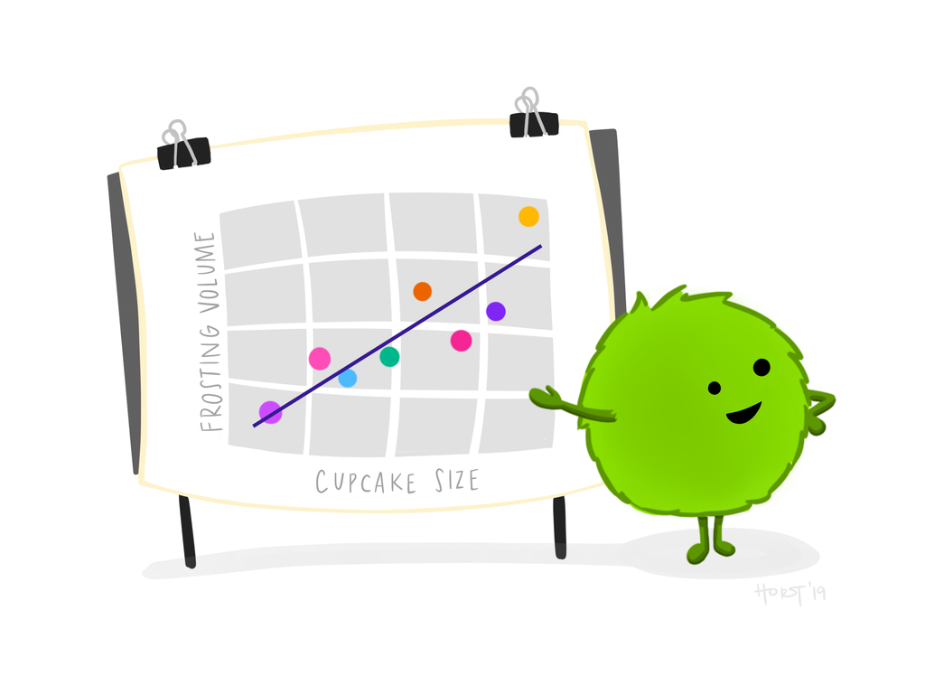

*Artist: Allison Horst*

### Review: Classification

In classification, we want to predict a *categorical* variable

- What political party will someone vote for in the next US election?
- Is a new patient diseased or healthy?
- Is a new email spam or not?
- Will a new, potential customer buy your product?

### Review: Regression

In regression, we want to predict a *quantitative* variable

E.g. predict the price of a 2000 square foot home:

[figure not shown]

### Linear Regression

Last time we used a nearest neighbours approach. Today we will find the line of "best-fit" through the data points:

[figure not shown]

### Linear Regression

And then we "look up" the value we want to predict of off of the line.

[figure not shown]

### Linear Regression

How do we choose the line of "best fit"? We can draw many lines through the data:

[figure not shown]

### Linear Regression

Just like last time, we will evaluate our model using the error in our predictions.

We choose the line that minimzes the RMSE (square root of average squared vertical distance between prediction and training data response value).

[figure not shown]

*Why did I say "RMSE" and not "RMSPE" above?*

### Linear Regression

The equation for a straight line is: $Y = \beta_0 + \beta_1X$

- $\beta_0$ is the y-intercept of the line (the value where the line cuts the y-axis)
- $\beta_1$ is the slope of the line

Finding the "line of best fit" = finding the values of $\beta_0, \beta_1$ that result in the lowest RMSE!

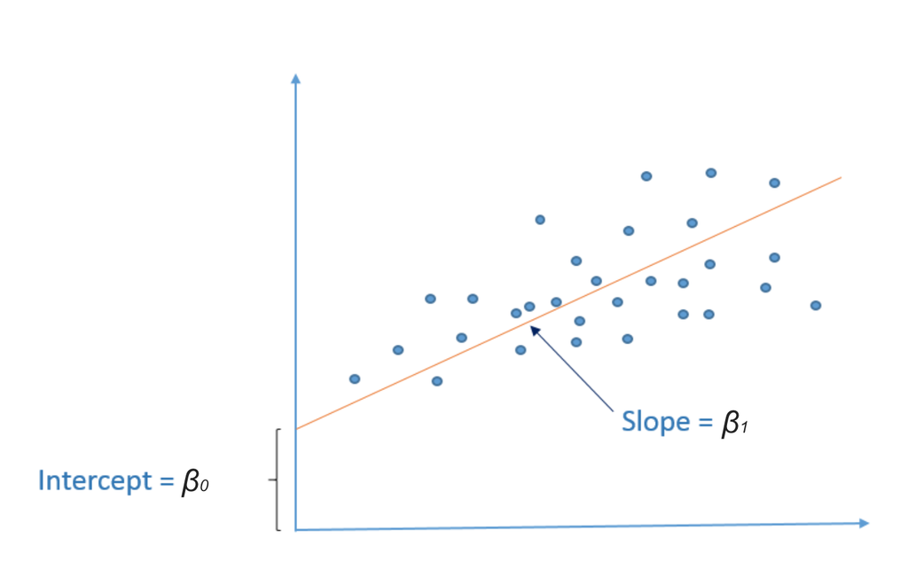

### Demo

Let's find the line of best fit (i.e., find $\beta_0, \beta_1$) for the housing data!

```python
import pandas as pd
from sklearn.model_selection import train_test_split
from sklearn.linear_model  import LinearRegression
```

### Demo

Let's find the line of best fit (i.e., find $\beta_0, \beta_1$) for the housing data!

```python
house_data.head()
```

|  | city | beds | baths | sqft | price |
| --- | --- | --- | --- | --- | --- |
| 0 | SACRAMENTO | 2 | 1.0 | 836 | 59222 |
| 1 | SACRAMENTO | 3 | 1.0 | 1167 | 68212 |
| 2 | SACRAMENTO | 2 | 1.0 | 796 | 68880 |
| 3 | SACRAMENTO | 2 | 1.0 | 852 | 69307 |
| 4 | SACRAMENTO | 2 | 1.0 | 797 | 81900 |

### Demo

Let's find the line of best fit (i.e., find $\beta_0, \beta_1$) for the housing data!

```python
# 1. create training data

sacramento_train, sacramento_test = train_test_split(house_data, train_size=0.6, random_state=1234)
X_train = sacramento_train[['sqft']]
y_train = sacramento_train['price']

# 2. create the model specification and recipe

lm = LinearRegression()

# 3. put it together in a workflow and fit

lm.fit(X_train, y_train)

lm.coef_
#lm.intercept_
# 4. view 𝛽0 (intercept), and 𝛽1(slope)

pd.DataFrame({"intercept": lm.intercept_, 'slope': lm.coef_})
```

|  | intercept | slope |
| --- | --- | --- |
| 0 | 22096.546 | 133.468486 |

We can then write:

$(\text{house price}) = \beta_0 + \beta_1\times(\text{house size})$

And finally, fill in the values for $\beta_0$ and $\beta_1$:

$(\text{house price}) = 22096.546 + 133.46\times(\text{house size})$

[figure not shown]

### Linear Regression vs Nearest Neighbours

- Advantages of straight line:
  - **interpretable:** coefficients are slopes, intercepts; K-NN not easy to interpret
  - **computation-efficient:** can fit the model much faster than K-NN
  - **data-efficient:** needs far fewer data to find a reasonable fit
- Major disadvantage of straight line: cannot capture nonlinear patterns

[figure not shown]

### Multiple Linear Regression

We can do regression with > 1 predictor. But how do we fit a line with many predictors?

We don't fit a line - we fit a *hyperplane*! e.g. for $m$ predictors: $$Y = \beta_0 + \beta_1 X_1 + \beta_2 X_2 + \dots + \beta_m X_m$$

- $\beta_0$: intercept
- $\beta_i$: slope for variable $i=1, \dots, m$

[figure not shown]

https://ubc-dsci.github.io/introduction-to-datascience/regression2.html#multivariate-linear-regression

### Why/why not linear/k-nn regression?

Models are not "one-size fits all."

```python
zigzag_plot
```

[interactive chart not shown]

### Why/why not linear/k-nn regression?

Models are not "one-size fits all."

```python
circle_plot
```

[interactive chart not shown]

## Worksheet time - go for it!

[figure not shown]